# Model diagnostics for Leaf 16S 3-level occupancy model.

## Load the model and packages

```
This is posterior version 1.5.0
```

[output not shown]

## MCMC diagnostics

Basic MCMC diagnostic checks. Models with divergent transitions, or large numbers of max_treedepth errors, are likely problematic and need refinement.

```
$num_divergent
[1] 0 0 0 0

$num_max_treedepth
[1] 0 0 0 0

$ebfmi
[1] 0.6956574 0.8243208 0.7768576 0.7787974
```

### Rhats

Rhat is a parameter-level summary statistic that attempts to summarise the convergence of a set of HMC/MCMC chains. A value close to 1 (approximately < 1.05) indicates chain convergence for that parameter. Below is a histogram of Rhat values for all model parameters, giving a rough at-a-glance summary of model convergence.

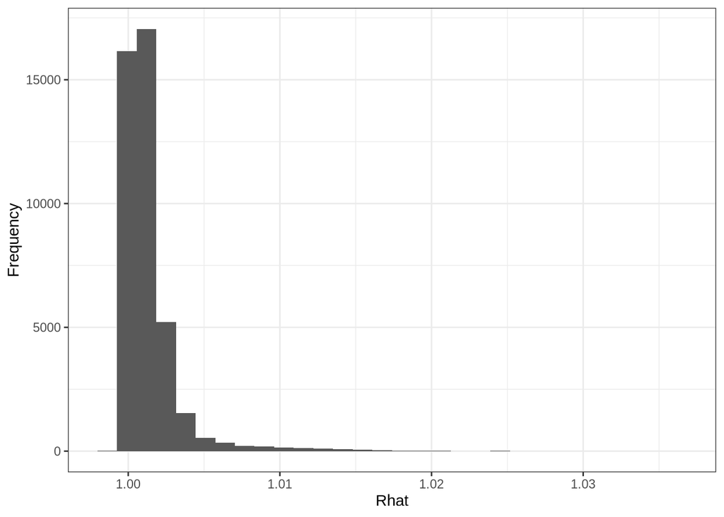

It should be noted that while this is a good rough guide, it is still important to inspect the MCMC chains more closely to gain further assurances of convergence.

### Trace plots

Below are MCMC traceplots for a selection of parameters of different types, to give a better overview of any convergence problems that may have occurred.

#### Sigmas

Site occupancy sigmas:

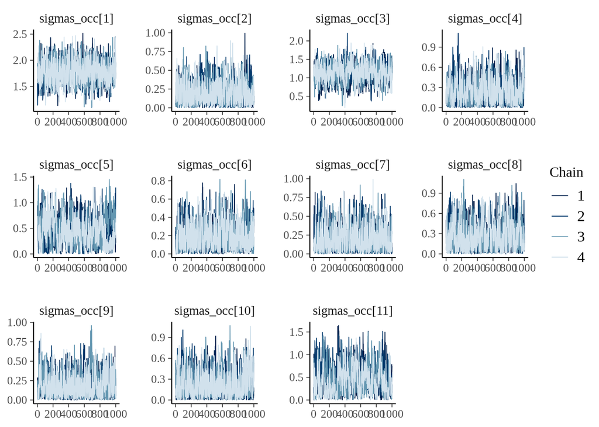

Sample occupancy sigmas:

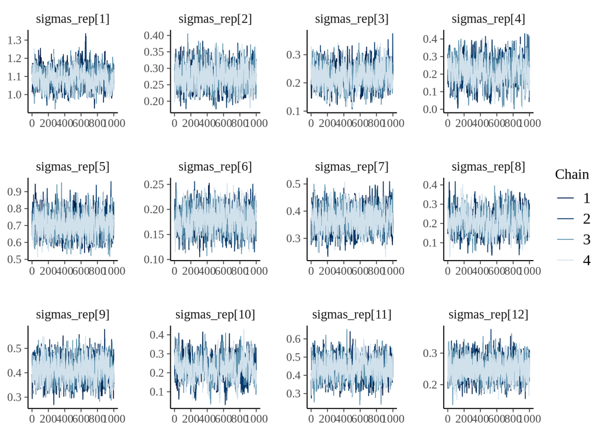

Detection sigmas:

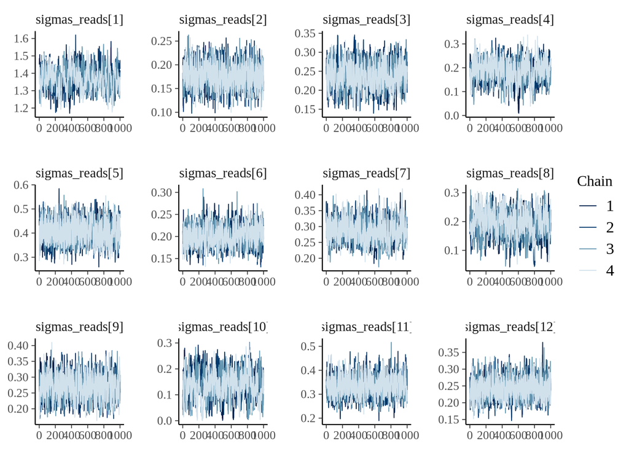

#### Fixed effects

Site occupancy:

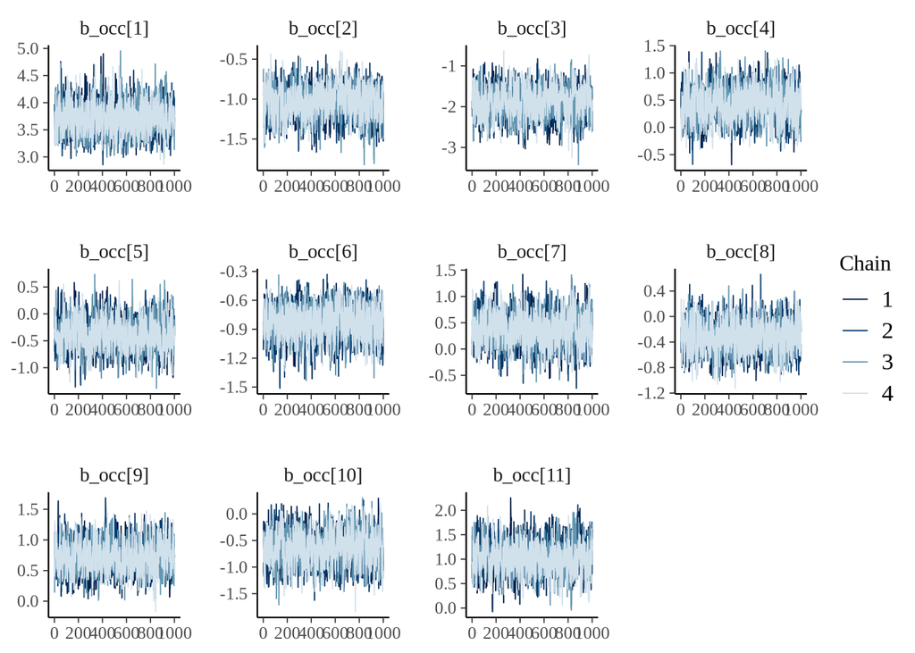

Sample occupancy:

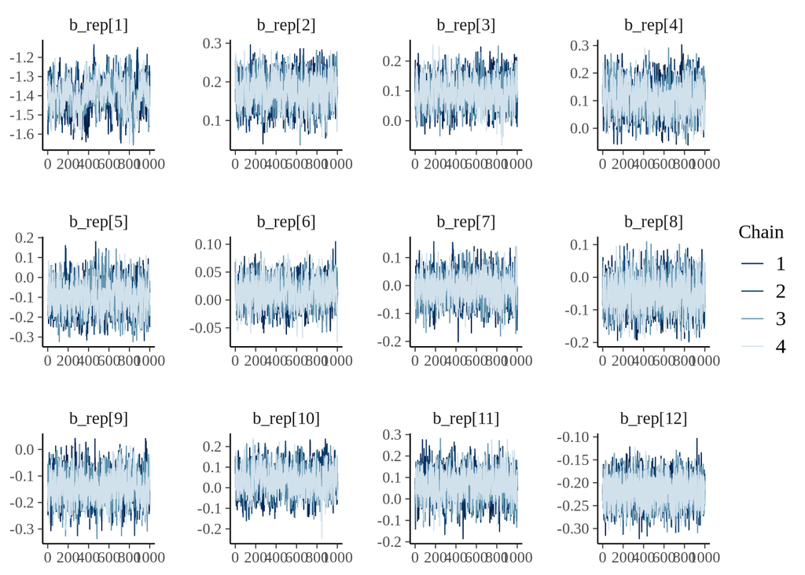

Detection:

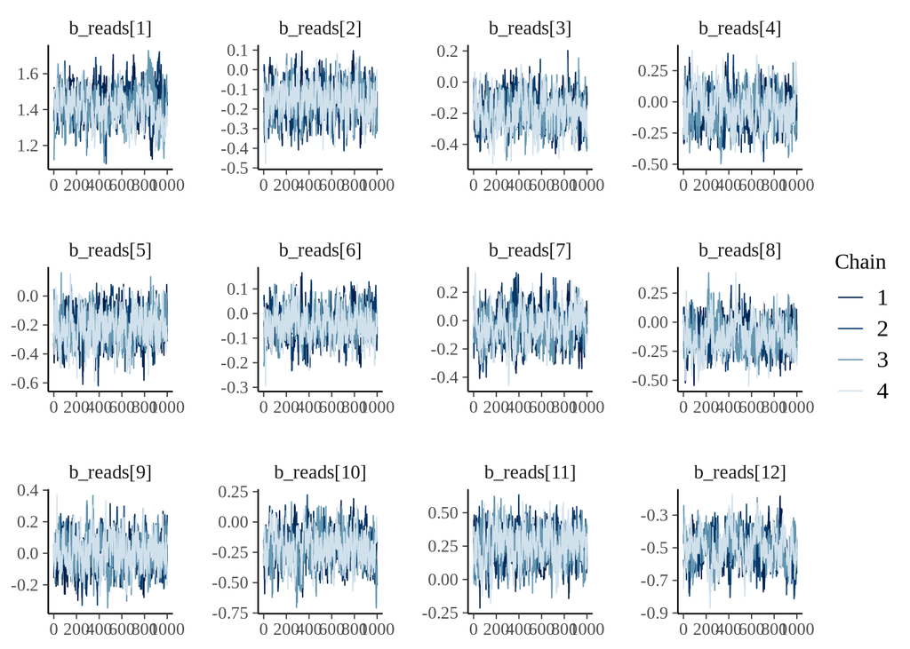

#### Species effects

Choose three random species to evaluate for:

```r
n_spp <- posterior::subset_draws(model_draws, "b_occ_species") |> as_draws_rvars() |> pluck("b_occ_species") |> ncol()
spp <- sample(n_spp, size = 3)

spp
```

```
[1] 136 341 395
```

Site occupancy:

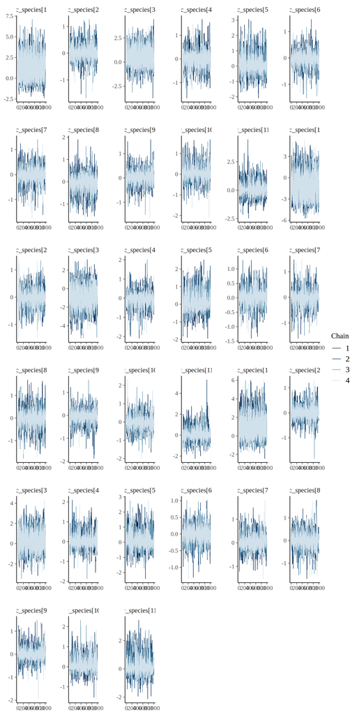

Sample occupancy:

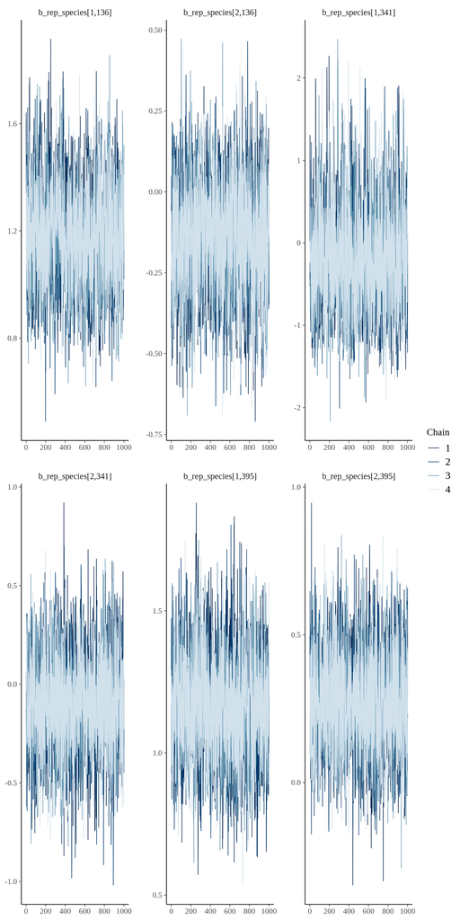

Detection:

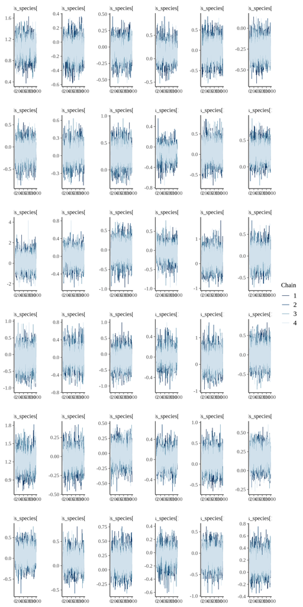

#### Dispersion

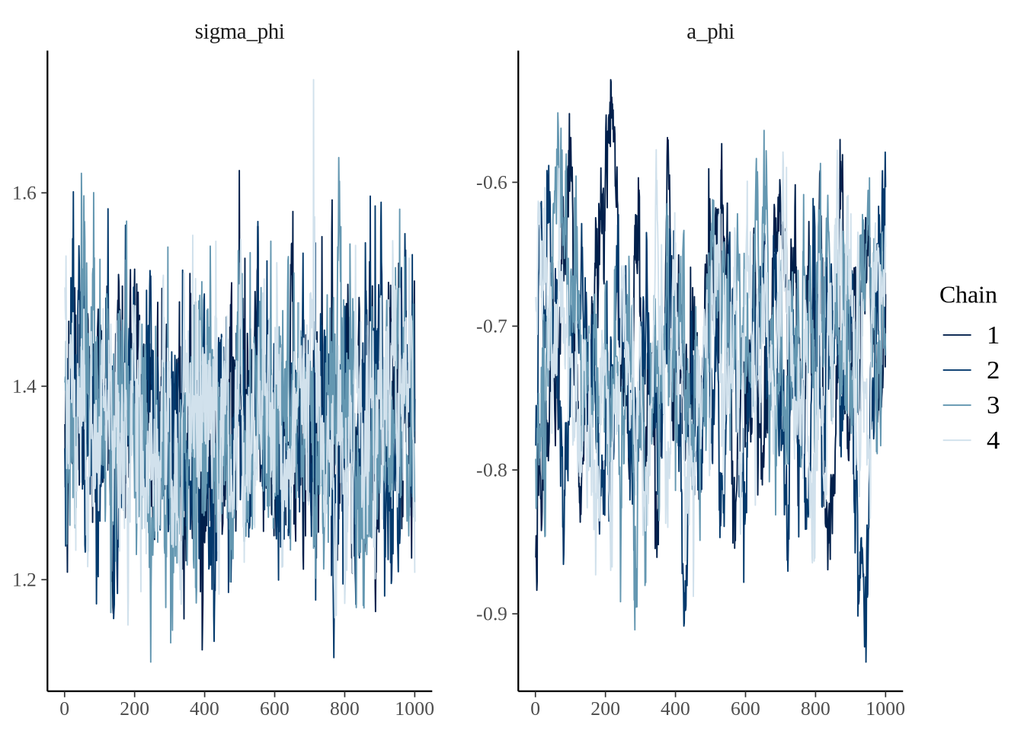

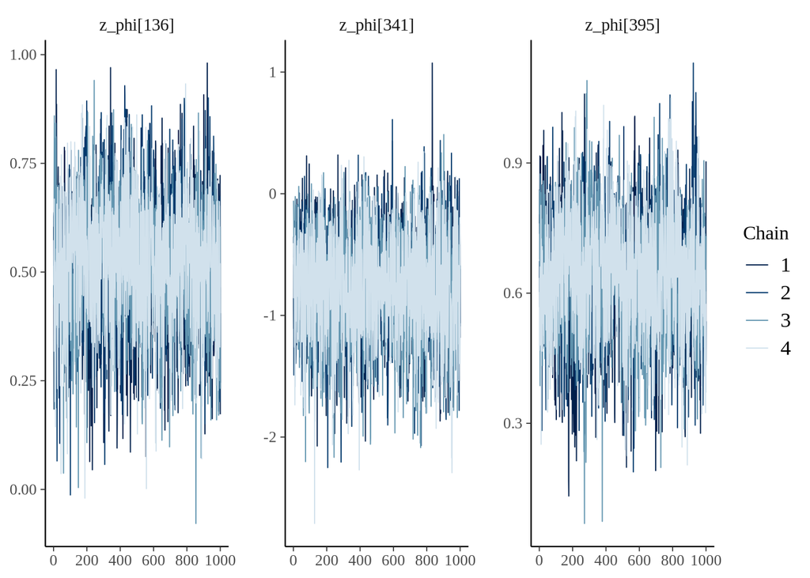

#### Size factors

```r
n_size_factors <-  posterior::subset_draws(model_draws, "SF") |> as_draws_rvars() |> pluck("SF") |> length()
sfs <- sample(n_size_factors, 10)

sfs
```

```
 [1] 266 119  21  63 196  73  71 183 243 136
```

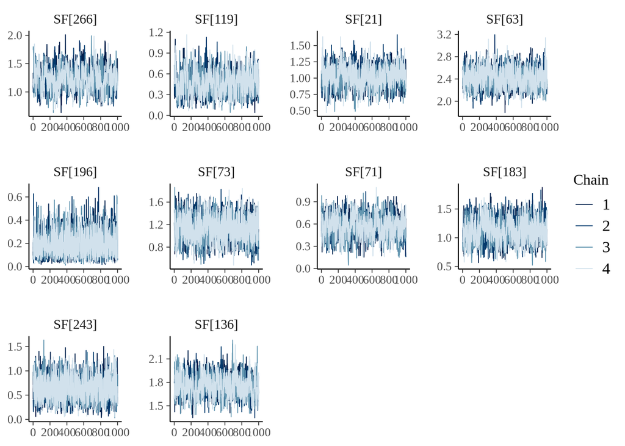

```r
posterior::subset_draws(model_draws, c("SF")) |> bayesplot::mcmc_trace(pars = vars(param_range("SF", sfs)))
```

## Leave-one-out cross-validation

Assuming MCMC diagnostics have passed, below is the leave-one-out cross validation score for the model, with moment matching.

```r
n_pars <- model_summary |>
  filter(!str_detect(variable, "species")) |>
  filter(variable != "phi") |>
  filter(variable != "log_lik")

n_pars
```

```
# A tibble: 27,917 × 10
   variable       mean   median      sd     mad       q5      q95  rhat ess_bulk
   <chr>         <dbl>    <dbl>   <dbl>   <dbl>    <dbl>    <dbl> <dbl>    <dbl>
 1 lp__       -1.46e+5 -1.46e+5 110.    108.    -1.46e+5 -1.46e+5  1.00     738.
 2 b_occ[1]    3.71e+0  3.70e+0   0.276   0.272  3.27e+0  4.18e+0  1.00    1343.
 3 b_occ[2]   -1.04e+0 -1.03e+0   0.191   0.194 -1.36e+0 -7.37e-1  1.00    1074.
 4 b_occ[3]   -1.91e+0 -1.90e+0   0.353   0.359 -2.49e+0 -1.33e+0  1.01     643.
 5 b_occ[4]    4.27e-1  4.21e-1   0.298   0.290 -7.20e-2  9.25e-1  1.00     969.
 6 b_occ[5]   -3.83e-1 -3.91e-1   0.287   0.275 -8.34e-1  1.13e-1  1.01     779.
 7 b_occ[6]   -8.34e-1 -8.30e-1   0.162   0.161 -1.11e+0 -5.80e-1  1.00    1634.
 8 b_occ[7]    3.65e-1  3.59e-1   0.303   0.296 -1.28e-1  8.66e-1  1.00    1072.
 9 b_occ[8]   -3.19e-1 -3.16e-1   0.231   0.230 -6.97e-1  6.51e-2  1.00    1347.
10 b_occ[9]    7.16e-1  7.11e-1   0.242   0.243  3.35e-1  1.13e+0  1.01     847.
# ℹ 27,907 more rows
# ℹ 1 more variable: ess_tail <dbl>
```

```r
loo$estimates
```

```
            Estimate         SE
elpd_loo -127468.055 1939.36491
p_loo       4444.328   73.00674
looic     254936.109 3878.72982
```

## Goodness-of-fit

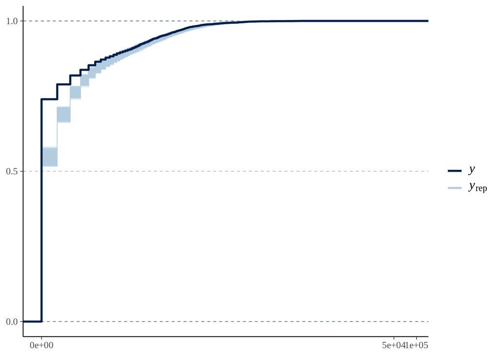

```r
Y <- model_data$Y |> {\(x) x[,,1]}() |> as.vector()
Y_rep <- model_postpreds$Y_rep |>
  t() |>
  as.vector()

len_Y <- length(Y)
max_sample <- 5000
if(len_Y > max_sample) {
  which_Y <- sample(1:len_Y, size = max_sample)
} else {
  which_Y <- 1:len_Y
}

bayesplot::ppc_ecdf_overlay(y = Y[which_Y],
                    yrep = draws_of(Y_rep[which_Y]),
                    discrete = TRUE
                    ) +
  scale_x_continuous(trans = "pseudo_log")
```

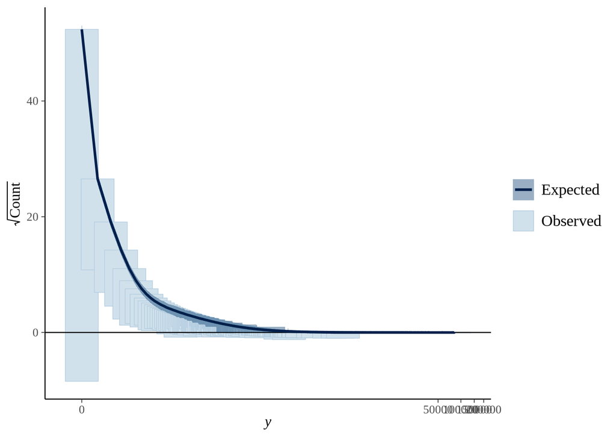

```r
bayesplot::ppc_rootogram(y = Y[which_Y],
                    yrep = draws_of(Y_rep[which_Y]),
                    style = "hanging"
                    ) +
  scale_x_continuous(trans = "pseudo_log")
```